# Sample Analysis

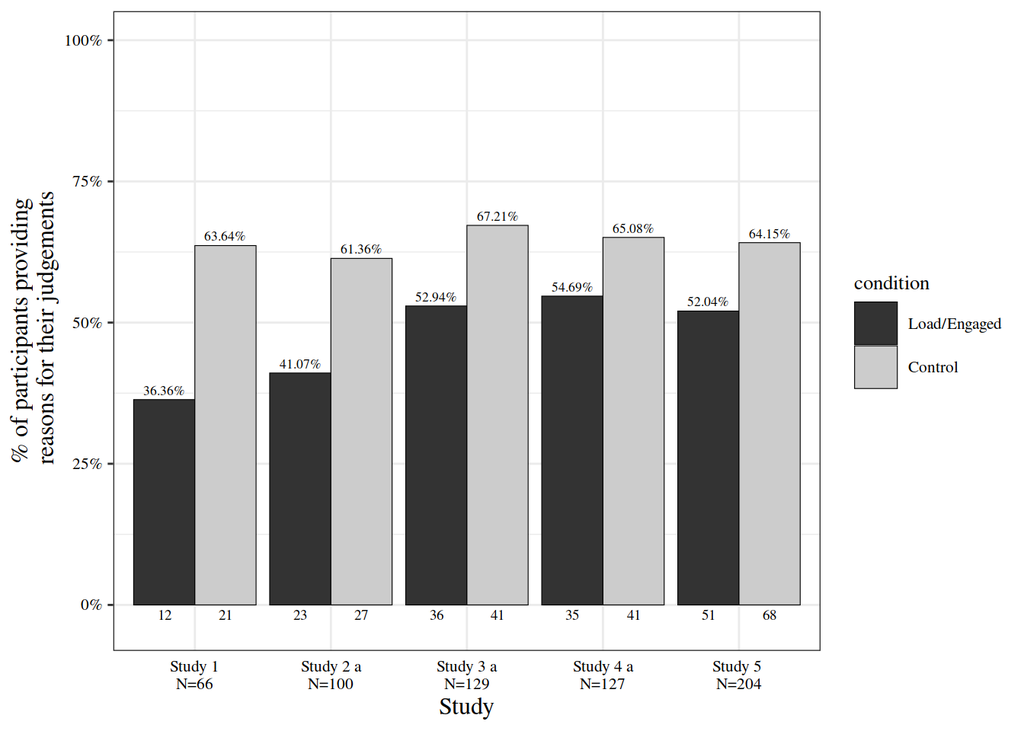

Figure 10: Rates of declaring reasons and cognitive load across each study

```r
ggplot(test, aes(x = Study, y = percent, fill = condition)) +
  scale_y_continuous(limits = c(-.03,1),
                     labels = percent_format()
                     )+
  geom_col(position = "dodge",
           color="black",
           size=.2
           )+
  geom_text(family = "Times", size=2.3,
            aes( label = scales::percent(test$percent),
                 y= test$percent ),
            stat= "identity",
            vjust = -.5,
            position = position_dodge(.9),
            fontface='plain'
            )+
  geom_text(family = "Times", size=2.5,
            aes(label = format(N),
                y= -3*(..count../100)/..count..),
            stat= "count",
            position = position_dodge(0.9),
            vjust = -.2,
            fontface='plain'
            )+
  labs(y = "% of participants providing\n reasons for their judgements",
       fil = ""
       )+
  theme_apa()+
  # scale_fill_manual(values = c("#333333", "#989898", "#B4B4B4", "#E6E6E6"),
  #                   labels=c("Study 1\nN=31",
  #                          "Study 2\nN=72",
  #                          "Study 3a\nN=72",
  #                          "Study 3b\nN=101"))+
  # scale_fill_grey(labels=c("Study 1\nN=66",
  #                          "Study 2 a\nN=100",
  #                          "Study 3 a\nN=129",
  #                          "Study 4 a\nN=127",
  #                          "Study 5 \nN=204",
  #                          "All studies a\nN=626",
  #                          "All studies b\nN=617")
  #                 )+
  scale_x_discrete(labels=c("Study 1\nN=66"
                            ,"Study 2 a\nN=100"
                            ,"Study 3 a\nN=129"
                            ,"Study 4 a\nN=127"
                            ,"Study 5 \nN=204"
                            #,"All studies a\nN=626"
                            #,"All studies b\nN=617"
                            )
                  )+
  # scale_fill_brewer(palette="OrRd") +
  # scale_fill_discrete(labels=c("Study 1\nN=66",
  #                          "Study 2 a\nN=100",
  #                          "Study 3 a\nN=129",
  #                          "Study 4 a\nN=127",
  #                          "Study 5 \nN=204",
  #                          "All studies a\nN=626",
  #                          "All studies b\nN=617")
  #                 )+
  # scale_x_discrete(labels = c("Load/Engaged","Control")
  #                  )+
  scale_fill_grey(labels = c("Load/Engaged","Control")
                   )+
  theme_bw() +
  theme(plot.title=element_text(family="Times",
                                size=12
                                ),
        legend.text=element_text(family="Times",
                                 size=8
                                 ),
          legend.title=element_text(family="Times",
                                    size=10
                                    ),
          axis.text=element_text(family="Times",
                                 colour = "black",
                                 size=8
                                 ),
          axis.ticks.x = element_blank(),
          axis.title=element_text(family="Times",
                                  size=12
                                  ),
          strip.text=element_text(family = "Times",
                                  size = 12
                                  ),
          strip.background = element_rect(fill = "white"),
          legend.position="right",
        legend.key.size = unit(1.5, "lines"))
```

```r
rm(test)
```

```r
# df3 <- zero_one_two_three
# df3 <- zero_one_two_three_five
# df3 <- three
df3 <- zero_one_two_three_five
df3$InCS <- relevel(df3$InCS, ref = 2)

df3a <- mlogit.data(df3, choice = "InCS", shape = "wide")
#InCSModel<-mlogit(InCS ~ 1 | NFC + condition, data = df3a, reflevel = 2)
InCSModel<-mlogit(InCS ~ 1 | NFC, data = df3a, reflevel = "It's wrong and I can provide a valid reason.")

summary_InCS_model <- summary(InCSModel)
summary_InCS_model$lratio$parameter
```

```
## df
##  2
```

```r
summary_InCS_model$lratio$statistic
```

```
## 'log Lik.' 12.15313 (df=4)
```

```r
summary_InCS_model$lratio$p.value
```

```
## 'log Lik.' 0.002296056 (df=4)
```

```r
InCSModel$coefficients[3]
```

```
## NFC:It's wrong but I can't think of a reason.
##                                    -0.2378214
```

```r
InCSModel$coefficients[4]
```

```
## NFC:There is nothing wrong.
##                1.486812e-05
```

```r
cox <- PseudoR2(multinom(InCS~NFC,df3), "all")
cox[3]
```

```
##   CoxSnell
## 0.01841118
```

```r
cox[4]
```

```
## Nagelkerke
## 0.02138562
```

```r
#PseudoR2(x, "all")
summary_InCS_model
```

```
##
## Call:
## mlogit(formula = InCS ~ 1 | NFC, data = df3a, reflevel = "It's wrong and I can provide a valid reason.",
##     method = "nr")
##
## Frequencies of alternatives:choice
## It's wrong and I can provide a valid reason.
##                                      0.56422
##    It's wrong but I can't think of a reason.
##                                      0.20642
##                      There is nothing wrong.
##                                      0.22936
##
## nr method
## 4 iterations, 0h:0m:0s
## g'(-H)^-1g = 0.00426
## successive function values within tolerance limits
##
## Coefficients :
##                                                          Estimate  Std. Error
## (Intercept):It's wrong but I can't think of a reason. -8.9657e-01  1.0490e-01
## (Intercept):There is nothing wrong.                   -9.0016e-01  1.0826e-01
## NFC:It's wrong but I can't think of a reason.         -2.3782e-01  7.1683e-02
## NFC:There is nothing wrong.                            1.4868e-05  6.9811e-02
##                                                       z-value  Pr(>|z|)
## (Intercept):It's wrong but I can't think of a reason. -8.5466 < 2.2e-16 ***
## (Intercept):There is nothing wrong.                   -8.3151 < 2.2e-16 ***
## NFC:It's wrong but I can't think of a reason.         -3.3177 0.0009076 ***
## NFC:There is nothing wrong.                            0.0002 0.9998301
## ---
## Signif. codes:  0 '***' 0.001 '**' 0.01 '*' 0.05 '.' 0.1 ' ' 1
##
## Log-Likelihood: -638.98
## McFadden R^2:  0.0094201
## Likelihood ratio test : chisq = 12.153 (p.value = 0.0022961)
```

```r
wald1 <-
  summary_InCS_model$CoefTable[3]^2 /
  summary_InCS_model$CoefTable[7]^2

wald2 <-
  summary_InCS_model$CoefTable[4]^2 /
  summary_InCS_model$CoefTable[8]^2


summary_InCS_model
```

```
##
## Call:
## mlogit(formula = InCS ~ 1 | NFC, data = df3a, reflevel = "It's wrong and I can provide a valid reason.",
##     method = "nr")
##
## Frequencies of alternatives:choice
## It's wrong and I can provide a valid reason.
##                                      0.56422
##    It's wrong but I can't think of a reason.
##                                      0.20642
##                      There is nothing wrong.
##                                      0.22936
##
## nr method
## 4 iterations, 0h:0m:0s
## g'(-H)^-1g = 0.00426
## successive function values within tolerance limits
##
## Coefficients :
##                                                          Estimate  Std. Error
## (Intercept):It's wrong but I can't think of a reason. -8.9657e-01  1.0490e-01
## (Intercept):There is nothing wrong.                   -9.0016e-01  1.0826e-01
## NFC:It's wrong but I can't think of a reason.         -2.3782e-01  7.1683e-02
## NFC:There is nothing wrong.                            1.4868e-05  6.9811e-02
##                                                       z-value  Pr(>|z|)
## (Intercept):It's wrong but I can't think of a reason. -8.5466 < 2.2e-16 ***
## (Intercept):There is nothing wrong.                   -8.3151 < 2.2e-16 ***
## NFC:It's wrong but I can't think of a reason.         -3.3177 0.0009076 ***
## NFC:There is nothing wrong.                            0.0002 0.9998301
## ---
## Signif. codes:  0 '***' 0.001 '**' 0.01 '*' 0.05 '.' 0.1 ' ' 1
##
## Log-Likelihood: -638.98
## McFadden R^2:  0.0094201
## Likelihood ratio test : chisq = 12.153 (p.value = 0.0022961)
```

```r
summary_InCS_model$coefficients[3]
```

```
## NFC:It's wrong but I can't think of a reason.
##                                    -0.2378214
```

```r
data.frame(exp(InCSModel$coefficients))
```

```
##                                                       exp.InCSModel.coefficients.
## (Intercept):It's wrong but I can't think of a reason.                   0.4079680
## (Intercept):There is nothing wrong.                                     0.4065036
## NFC:It's wrong but I can't think of a reason.                           0.7883435
## NFC:There is nothing wrong.                                             1.0000149
```

```r
exp(InCSModel$coefficients)[3]
```

```
## NFC:It's wrong but I can't think of a reason.
##                                     0.7883435
```

```r
a <- exp(confint(InCSModel))
c(a[3],a[7])
```

```
## [1] 0.6850133 0.9072605
```

```r
residuals(InCSModel)
```

[output not shown]

[output cut: 79 more lines]

```r
fitted(InCSModel, outcome = F)
```

[output not shown]

[output cut: 1295 more lines]

```r
c <- summary_InCS_model$lratio$statistic
w <- sqrt(c/length(df3$gender))
pw <- pwr.chisq.test(w=w,N=length(df3$InCS),df=(2),sig.level = .05)

pw$power
```

```
## [1] 0.8873151
```

```r
revised_PseudoR2s <- function(LogModel) {
  dev <- LogModel$deviance
  nullDev <- LogModel$null.deviance
  modelN <- length(LogModel$fitted.values)
  R.l <- 1 - dev / nullDev
  R.cs <- 1- exp ( -(nullDev - dev) / modelN)
  R.n <- R.cs / ( 1 - ( exp (-(nullDev / modelN))))

  all <- list(hosmer_and_lemeshow = as.numeric(R.l), mcfadden = NA, cox_and_snell = as.numeric(R.cs), nagelkerke = as.numeric(R.n))
  all
}

logits_rsquared <- glm(InCS~NFC+condition,df3, family = binomial(link = "logit"))
cox <- revised_PseudoR2s(logits_rsquared)
```

```r
df3 <- df3[which(is.na(df3$NFC)==FALSE),]

cbind.data.frame(df3$InCS,as.numeric(df3$InCS))
```

[output not shown]

[output cut: 640 more lines]

```r
x <- df3$NFC
y <- as.numeric(df3$InCS)

m1 <- multinom(y ~ x)
```

```r
# summary(m1)
newdata <- data.frame(x = seq(min(x), max(x), length.out = 100))
p1 <- predict(m1, newdata, type = "class")
p2 <- predict(m1, newdata, type = "probs")


logit_plot <- cbind.data.frame(newdata,p2)

logit_plot <- `colnames<-`(logit_plot, c("x","one_l","two_l","three_l"))
logit_plot <- melt(logit_plot, id="x")
```

## Need for Cognition

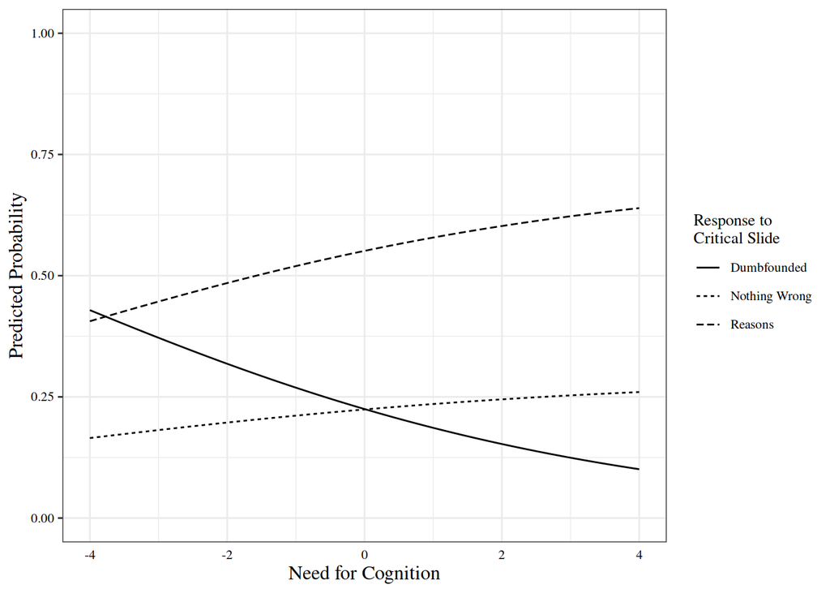

Figure 11: Studies 1-5: Probability of selecting each response to the critical slide depending on Need for Cognition

```r
ggplot(logit_plot,
       aes(x=x, y=value,
           #color=factor(variable,labels=c("dumb","reason","nothing"))
           linetype=factor(variable
                           #,labels=c("dumb","reason","nothing")
                           )
           )) +
  geom_line()+
  xlab("Need for Cognition") + ylab("Predicted Probability") +
  scale_y_continuous(limits = c(0, 1)) +
  #scale_color_discrete(name="Response to \nCritical Slide", labels=c("Dumbfounded","Nothing Wrong","Reasons"))+
  scale_linetype_discrete(name="Response to \nCritical Slide"
                          , labels=c("Dumbfounded","Nothing Wrong","Reasons")
                          )+
  theme_bw() +
  theme(plot.title=element_text(family="Times",
                                size=12
  ),
  legend.text=element_text(family="Times",
                           size=8
  ),
  legend.title=element_text(family="Times",
                            size=10
  ),
  axis.text=element_text(family="Times",
                         colour = "black",
                         size=8
  ),
  axis.ticks.x = element_blank(),
  axis.title=element_text(family="Times",
                          size=12
  ),
  strip.text=element_text(family = "Times",
                          size = 12
  ),
  strip.background = element_rect(fill = "white"),
  legend.position="right")
```

# General Discussion

We conducted five studies to test a conflict in dual-processes explanation of moral dumbfounding. We hypothesised that moral dumbfounding emerges as a result of conflict between a habitual/intuitive response and deliberation. We found some evidence in support of this explanation of moral dumbfounding. This evidence was not as strong as expected. This may be due to limitations in the methods employed, or it may be evidence that the explanation tested here does not capture the full complexity of the phenomenon.

## Interpreting the Results

The relative roles of intuition and deliberation in producing each of the possible responses in the dumbfounding paradigm were identified, and these responses were ranked according to level of deliberation involved in each. The responses are as follows: (1) reason; (2) nothing wrong; and (3) dumbfounding. We hypothesised that, (1) a reason response involves the most deliberation. The relative roles of intuition and deliberation in the remaining responses were less clear, particularly because of the possibility of that competing intuitions may emerge. If deliberation fails to identify justifications for an initial intuition, a person may find that they must choose between two competing intuitions (initial judgement; that moral judgements should be justifiable). Despite this limitation, a clear candidate for relying on deliberation the most was identified: (1) reason.

### Cognitive load and Providing Reasons

Having identified a response that clearly relied on deliberation more than the other responses, an experimental manipulation that is known to influence deliberative responding was selected for study: cognitive load (De Neys, 2006; Evans & Curtis-Holmes, 2005; Evans & Stanovich, 2013; Schmidt, 2016). In addition to this, an individual difference variable that has to been linked to a tendency to engage in deliberation was identified and selected for investigation (Need for Cognition, Cacioppo & Petty, 1982; Evans & Stanovich, 2013; Petty, Cacioppo, & Kao, 1984). Five studies were conducted investigating cognitive load and moral dumbfounding. The target response was “It’s wrong and I can provide a valid reason” on the critical slide. We hypothesised that cognitive load would inhibit participants’ ability to provide reasons for their judgements, and that under cognitive load reduced incidences of participants stating they could provide a reason would be observed. We also hypothesised that providing reasons would be related to Need for Cognition scores, such that participants who score higher on Need for Cognition would be more likely to provide reasons than select any other response on the critical slide.

Study 1 showed a clear reduction in providing reasons for a judgement depending on cognitive load (resulting in an increase in selecting “There is nothing wrong”). The results of Study 2 indicated that any effect cognitive load had on ability to generate reasons for a judgement was related to level of engagement with the cognitive load task. Study 3 demonstrated that when controlling for engagement with the cognitive load task, cognitive load led to higher rates of dumbfounding. However, Studies 4 and 5 failed to replicate these findings. Three studies described here therefore showed that participants actively engaging with cognitive load task were consistently less effective at identifying reasons for their judgements. Studies 4 and 5 showed a similar pattern of responses, however this was not statistically significant.

### Need for Cognition in the Dumbfounding Paradigm

There was no significant relationship between Need for Cognition and the critical slide for Studies 1, 2, 4, and 5. In Study 3, higher Need for Cognition predicted higher rates of providing reasons than dumbfounded responding. In the combined analysis, higher Need for Cognition scores predicted higher rates of both providing reasons and selecting “there is nothing wrong” and reduced rates of dumbfounded responding.

### Key Findings

The combined results of Studies 1-5 appear to indicate that engaging in a cognitive load task leads to reduced incidences of providing reasons (as hypothesised). Studies 4 and 5 to failed replicate this effect, so caution is advised when interpreting this result, however, given the consistency in the pattern of responses, the clear result in the combined analysis, and in the meta-analysis, it is likely that the failure to replicate the effect was due to a lack of statistical power. Furthermore, dumbfounded responding appeared to be linked to lower Need for Cognition scores. Again, caution is advised in interpreting this result, particularly given that only 1 (Study 3) of the Studies 1-5 individually found any relationship between Need for Cognition and response to the critical slide.

## Implications

Overall, the results of the studies described here provide some evidence for the conflict in dual-processes explanation of moral dumbfounding identified here, however the inconsistencies in the results poses a challenge to this finding. Despite the inconsistencies, the studies described here do not provide convincing evidence that this explanation of moral dumbfounding is wrong. From these somewhat mixed results, what seems clear is that moral dumbfounding is not a simple matter of habitual or deliberative responses. The complexity of moral dumbfounding becomes apparent when attempting to describe the various possible responses in the paradigm in terms of the relative roles of deliberation and intuition. The possibility that a failure of deliberation to provide reasons for an intuition may lead to alternative and competing intuitions to become salient means that in some cases, moral dumbfounding may involve conflict between competing intuitions.

The apparent conflict between competing intuitions is more complicated than conflict between intuition and deliberation. Recall that the examples of conflict identified above clearly pitted an intuitive response against a deliberative response, and resolution of this conflict was relatively straight forward. For example, in base-rate neglect problems there is only one correct answer. The intuitive response is incorrect and deliberation leads to an alternative response. This conflict is easily resolved because deliberation has clearly identified the intuitive response as incorrect. In contrast moral judgements are not clearly correct or incorrect and the failure of deliberation to identify reasons for an intuition is not necessarily evidence that the intuition is incorrect. That moral dumbfounding is more complicated than classic cases of conflict in dual-processes does not necessarily mean that attempting to explain moral dumbfounding as the result of dual-process conflict is without merit. It is possible that conflict in dual-processes is still implicated in moral dumbfounding. However, where conflict is normally resolved through suppression of erroneous intuitive responses, in the dumbfounding paradigm this conflict is not easily resolved leading participants are faced with a conflict between competing intuitions. Given that this explanation identifies dumbfounding as arising from conflict between competing intuitions (same underlying mechanisms) as opposed to conflict between intuition and deliberation (different underlying mechanisms) means that testing this explanation is particularly problematic.

## Limitations and Future Directions

There are a number of related limitations of the studies conducted here that may have contributed to the inconclusive results in different ways. Firstly, it is possible that the inconclusive result is due to limitations in the method of data collection employed across Studies 2, 3, and 4. Online data collection through MTurk is useful for ease of access to willing participants resulting in highly efficient data collection. However, the absence of oversight or supervision of participants taking part in the studies means that complex manipulations such as cognitive load manipulations may not be as successful as in a controlled laboratory setting (Crump, McDonnell, & Gureckis, 2013; Goodman, Cryder, & Cheema, 2013). In response to the difficulties in manipulating cognitive load in an online study, we conducted an additional study (Study 5) returning to a college sample where the study took place in a controlled environment, under the supervision of the experimenter.

The failure of Study 5 to replicate the findings of Studies 1, 2, and 3 may be due to the nature of the variables used. The dependent variable in these studies is nominal/categorical. This variable type is not well suited for identifying small or subtle effects; consider the extensive research identifying disgust effects on moral judgements (e.g., Cameron, Payne, & Doris, 2013; David & Olatunji, 2011; Landy & Goodwin, 2015; Rozin, Haidt, MacCauley, McKay, & Olatunji, 2008; Russell & Giner-Sorolla, 2011; Sabo & Giner-Sorolla, 2017; Schnall, Haidt, Clore, & Jordan, 2008; Wheatley & Haidt, 2005). May (2014) noted that the effect of incidental disgust is largely on the severity of a judgement, as opposed to altering the valence of the judgement. The use of a binary right/wrong measure of judgements therefore would fail to identify any effect for disgust on moral judgements. As such, the measures used in the dumbfounding paradigm mean that identifying influences on dumbfounding is particularly challenging, because minor influences on people’s ability to provide reasons may not yield measurable effects.

## Conclusion

The studies described here aimed to investigate if cognitive load influenced the degree to which people successfully identified reasons for their judgements. The individual difference variable Need for Cognition was also investigated.

For 4 of the 5 studies conducted, there did not appear to be a relationship between Need for Cognition and response to the critical slide, however in Study 3, and the final analysis of all the studies together, lower Need for Cognition scores were associated with dumbfounded responding. The effect size was quite small, and this effect only emerged in 1 study, and when all the data were combined. However, this may prove useful in furthering our understanding of moral dumbfounding and the making of moral judgements more generally. That dumbfounding may be weakly related to scoring lower on Need for Cognition is interesting and may provide a useful area for follow-up work.

The primary aim of this paper was to test a dual-process conflict explanation of moral dumbfounding. According to this view, providing reasons for a judgement is grounded in deliberation, and dumbfounded responding is grounded in habitual responding. The extent to which revising a judgement is grounded in deliberation or habitual responding is unclear, and may vary depending on the individual. The key prediction of this explanation is that inhibiting deliberative responding, through a cognitive load manipulation, would inhibit the identification of reasons.

The studies presented here offer suggestive evidence that cognitive load inhibits the identification of reasons in the dumbfounding paradigm. Engagement with the cognitive load manipulation on the part of the participants is essential for it to successfully inhibit the identification of reasons. The pattern of responses across the studies is consistent with the possibility that revising a judgement requires more deliberation than providing a dumbfounded response, however this claim was not tested directly, and there is no clear evidence in support of it. Some evidence in support of the primary prediction, that inhibiting deliberative responding should inhibit the identification of reasons was found. This suggests that a dumbfounded response is a more habitual/intuitive response whereas providing reasons relies more on deliberative responding. But that the processes that give rise to judgements and reason-giving in complex situations are not simply the operation dual-systems or a conflict between them, but a complex of interacting processes in which these aspects play a role.

# Data Accessibility Statement

All participant data, and analysis scripts can be found on this paper’s project page on the Open Science Framework at https://osf.io/wge5t/.

# References

```r
r_refs(file = "r-references.bib")
```

Abelson, R. P. (1988). Conviction. *American Psychologist*, *43*(4), 267–275. https://doi.org/10.1037/0003-066X.43.4.267

Amazon Web Services Inc. (2016). Amazon Mechanical Turk.

Aust, F. (2016). *Citr: ’RStudio’ Add-in to Insert Markdown Citations*.

Aust, F., & Barth, M. (2018). *Papaja: Create APA manuscripts with R Markdown*.

Bago, B., & De Neys, W. (2019). The intuitive greater good: Testing the corrective dual process model of moral cognition. *Journal of Experimental Psychology: General*, *148*(10), 1782–1801. https://doi.org/10.1037/xge0000533

Bates, D., & Maechler, M. (2017). *Matrix: Sparse and Dense Matrix Classes and Methods*.

Bates, D., Mächler, M., Bolker, B., & Walker, S. (2015). Fitting Linear Mixed-Effects Models Using Lme4. *Journal of Statistical Software*, *67*(1), 1–48. https://doi.org/10.18637/jss.v067.i01

Bonner, C., & Newell, B. R. (2010). In conflict with ourselves? An investigation of heuristic and analytic processes in decision making. *Memory & Cognition*, *38*(2), 186–196. https://doi.org/10.3758/MC.38.2.186

Brand, C. (2016). *Dual-Process Theories in Moral Psychology: Interdisciplinary Approaches to Theoretical, Empirical and Practical Considerations*. Springer.

Cacioppo, J. T., & Petty, R. E. (1982). The need for cognition. *Journal of Personality and Social Psychology*, *42*(1), 116–131. https://doi.org/10.1037/0022-3514.42.1.116

Cameron, C. D., Payne, B. K., & Doris, J. M. (2013). Morality in high definition: Emotion differentiation calibrates the influence of incidental disgust on moral judgments. *Journal of Experimental Social Psychology*, *49*(4), 719–725. https://doi.org/10.1016/j.jesp.2013.02.014

Champely, S. (2018). *Pwr: Basic Functions for Power Analysis*.

Chang, W. (2014). *Extrafont: Tools for using fonts*.

Crockett, M. J. (2013). Models of morality. *Trends in Cognitive Sciences*, *17*(8), 363–366. https://doi.org/10.1016/j.tics.2013.06.005

Croissant, Y. (2013). *Mlogit: Multinomial logit model*.

Croissant, Y. (2020). *Dfidx: Indexed data frames*. Manual.

Crump, M. J. C., McDonnell, J. V., & Gureckis, T. M. (2013). Evaluating Amazon’s Mechanical Turk as a Tool for Experimental Behavioral Research. *PLOS ONE*, *8*(3), e57410. https://doi.org/10.1371/journal.pone.0057410

Cushman, F. A. (2013). Action, Outcome, and Value A Dual-System Framework for Morality. *Personality and Social Psychology Review*, *17*(3), 273–292. https://doi.org/10.1177/1088868313495594

Cushman, F. A., Young, L., & Greene, J. D. (2010). Multi-system Moral Psychology. In J. M. Doris (Ed.), *The Moral Psychology Handbook* (pp. 47–71). Oxford; New York: Oxford University Press.

David, B., & Olatunji, B. O. (2011). The effect of disgust conditioning and disgust sensitivity on appraisals of moral transgressions. *Personality and Individual Differences*, *50*(7), 1142–1146. https://doi.org/10.1016/j.paid.2011.02.004

De Neys, W. (2006). Dual Processing in Reasoning: Two Systems but One Reasoner. *Psychological Science*, *17*(5), 428–433. https://doi.org/10.1111/j.1467-9280.2006.01723.x

De Neys, W. (2012). Bias and Conflict: A Case for Logical Intuitions. *Perspectives on Psychological Science*, *7*(1), 28–38. https://doi.org/10.1177/1745691611429354

De Neys, W., & Glumicic, T. (2008). Conflict monitoring in dual process theories of thinking. *Cognition*, *106*(3), 1248–1299. https://doi.org/10.1016/j.cognition.2007.06.002

De Neys, W., & Pennycook, G. (2019). Logic, Fast and Slow: Advances in Dual-Process Theorizing. *Current Directions in Psychological Science*, *28*(5), 503–509. https://doi.org/10.1177/0963721419855658

De Neys, W., & Schaeken, W. (2007). When people are more logical under cognitive load: Dual task impact on scalar implicature. *Experimental Psychology*, *54*(2), 128–133. https://doi.org/10.1027/1618-3169.54.2.128

Dewey, M. (2017). *Metap: Meta-analysis of significance values*.

Drolet, A., & Frances Luce, M. (2004). The Rationalizing Effects of Cognitive Load on Emotion-Based Trade-off Avoidance. *Journal of Consumer Research*, *31*(1), 63–77. https://doi.org/10.1086/383424

et mult. al., A. S. (2019). *DescTools: Tools for Descriptive Statistics*.

Evans, J. St. B. T. (2007). On the resolution of conflict in dual process theories of reasoning. *Thinking & Reasoning*, *13*(4), 321–339. https://doi.org/10.1080/13546780601008825

Evans, J. St. B. T. (2008). Dual-Processing Accounts of Reasoning, Judgment, and Social Cognition. *Annual Review of Psychology*, *59*(1), 255–278. https://doi.org/10.1146/annurev.psych.59.103006.093629

Evans, J. St. B. T., & Curtis-Holmes, J. (2005). Rapid responding increases belief bias: Evidence for the dual-process theory of reasoning. *Thinking & Reasoning*, *11*(4), 382–389. https://doi.org/10.1080/13546780542000005

Evans, J. St. B. T., & Stanovich, K. E. (2013). Dual-Process Theories of Higher Cognition: Advancing the Debate. *Perspectives on Psychological Science*, *8*(3), 223–241. https://doi.org/10.1177/1745691612460685

Forsterlee, R., & Ho, R. (1999). An Examination of the Short form of the Need for Cognition Scale Applied in an Australian Sample. *Educational and Psychological Measurement*, *59*(3), 471–480. https://doi.org/10.1177/00131649921969983

Fox, J., & Weisberg, S. (2011). *An R Companion to Applied Regression* (Second). Thousand Oaks CA: Sage.

Fox, J., Weisberg, S., & Price, B. (2018). *carData: Companion to Applied Regression Data Sets*.

Goodman, J. K., Cryder, C. E., & Cheema, A. (2013). Data Collection in a Flat World: The Strengths and Weaknesses of Mechanical Turk Samples. *Journal of Behavioral Decision Making*, *26*(3), 213–224. https://doi.org/10.1002/bdm.1753

Greene, J. D. (2008). The Secret Joke of Kant’s Soul. In *Moral Psychology Volume 3: The neurosciences of morality: Emotion, brain disorders, and development* (pp. 35–79). Cambridge (Mass.): the MIT press.

Greene, J. D., Morelli, S. A., Lowenberg, K., Nystrom, L. E., & Cohen, J. D. (2008). Cognitive load selectively interferes with utilitarian moral judgment. *Cognition*, *107*(3), 1144–1154. https://doi.org/10.1016/j.cognition.2007.11.004

Haidt, J. (2001). The emotional dog and its rational tail: A social intuitionist approach to moral judgment. *Psychological Review*, *108*(4), 814–834. https://doi.org/10.1037/0033-295X.108.4.814

Haidt, J., & Björklund, F. (2008). Social Intuitionists Answer Six Questions about Moral Psychology. In W. Sinnott-Armstrong (Ed.), *Moral psychology Volume 2, The cognitive science of morality: Intuition and diversity* (pp. 181–217). London: MIT.

Haidt, J., Björklund, F., & Murphy, S. (2000). Moral dumbfounding: When intuition finds no reason. *Unpublished Manuscript, University of Virginia*.

Just, M. A., & Carpenter, P. A. (1992). A capacity theory of comprehension: Individual differences in working memory. *Psychological Review*, *99*(1), 122–149. https://doi.org/10.1037/0033-295X.99.1.122

Kruglanski, A. W., & Webster, D. M. (1996). Motivated closing of the mind: "Seizing" and "freezing.". *Psychological Review*, *103*(2), 263–283. https://doi.org/10.1037/0033-295X.103.2.263

Kruglanski, A. W., Webster, D. M., & Klem, A. (1993). Motivated resistance and openness to persuasion in the presence or absence of prior information. *Journal of Personality and Social Psychology*, *65*(5), 861–876. https://doi.org/10.1037/0022-3514.65.5.861

Landy, J. F., & Goodwin, G. P. (2015). Does Incidental Disgust Amplify Moral Judgment? A Meta-Analytic Review of Experimental Evidence. *Perspectives on Psychological Science*, *10*(4), 518–536. https://doi.org/10.1177/1745691615583128

Lerner, M. J., & Goldberg, J. H. (1999). When Do Decent People Blame Victims? The Differing Effects of the Explicit/Rational and Implicit/Experiential Cognitive Systems. In S. Chaiken & Y. Trope (Eds.), *Dual-process Theories in Social Psychology* (pp. 627–640). Guilford Press.

Lüdecke, D. (2018). *Sjstats: Statistical Functions for Regression Models*.

May, J. (2014). Does Disgust Influence Moral Judgment? *Australasian Journal of Philosophy*, *92*(1), 125–141.

McGregor, I. (2006a). Offensive Defensiveness: Toward an Integrative Neuroscience of Compensatory Zeal After Mortality Salience, Personal Uncertainty, and Other Poignant Self-Threats. *Psychological Inquiry*, *17*(4), 299–308. https://doi.org/10.1080/10478400701366977

McGregor, I. (2006b). Zeal Appeal: The Allure of Moral Extremes. *Basic and Applied Social Psychology*, *28*(4), 343–348. https://doi.org/10.1207/s15324834basp2804_7

McGregor, I., Zanna, M. P., Holmes, J. G., & Spencer, S. J. (2001). Compensatory conviction in the face of personal uncertainty: Going to extremes and being oneself. *Journal of Personality and Social Psychology*, *80*(3), 472–488. https://doi.org/10.1037/0022-3514.80.3.472

McHugh, C. (2017). *Desnum: Creates some useful functions*. Manual.

McHugh, C., McGann, M., Igou, E. R., & Kinsella, E. L. (2017). Searching for Moral Dumbfounding: Identifying Measurable Indicators of Moral Dumbfounding. *Collabra: Psychology*, *3*(1), 1–24. https://doi.org/10.1525/collabra.79

McHugh, C., McGann, M., Igou, E. R., & Kinsella, E. L. (2020). Reasons or rationalizations: The role of principles in the moral dumbfounding paradigm. *Journal of Behavioral Decision Making*, *33*(3), 376–392. https://doi.org/10.1002/bdm.2167

Müller, K., & Wickham, H. (2020). *Tibble: Simple data frames*. Manual.

Navarro, D. (2015). *Learning statistics with R: A tutorial for psychology students and other beginners. (Version 0.5)*. Adelaide, Australia: University of Adelaide.

Petty, R. E., Cacioppo, J. T., & Kao, C. F. (1984). The efficient assessment of need for cognition. *Journal of Personality Assessment*, *48*(3), 306–307.

Petty, R. E., Feinstein, J. A., Blair, W., & Jarvis, G. (1996). Dispositional differences in cognitive motivation: The life and times of individuals varying in need for cognition. *Psych. Bull*, 197–253.

Prinz, J. J. (2005). Passionate Thoughts: The Emotional Embodiment of Moral Concepts. In D. Pecher & R. A. Zwaan (Eds.), *Grounding Cognition: The Role of Perception and Action in Memory, Language, and Thinking* (pp. 93–114). Cambridge University Press.

Qiu, W. (2018). *powerMediation: Power/Sample Size Calculation for Mediation Analysis*.

R Core Team. (2020a). *Foreign: Read data stored by ’minitab’, ’s’, ’SAS’, ’SPSS’, ’stata’, ’systat’, ’weka’, ’dBase’, ...* Manual.

R Core Team. (2020b). *R: A language and environment for statistical computing*. Manual, Vienna, Austria: R Foundation for Statistical Computing.

Royzman, E. B., Kim, K., & Leeman, R. F. (2015). The curious tale of Julie and Mark: Unraveling the moral dumbfounding effect. *Judgment and Decision Making*, *10*(4), 296–313.

Rozin, P., Haidt, J., MacCauley, C., McKay, D., & Olatunji, B. O. (2008). Disgust: The body and soul emotion in the 21st century. In *Disgust and its disorders* (pp. 9–29). American Psychological Association.

Rozin, P., Markwith, M., & McCauley, C. (1994). Sensitivity to indirect contacts with other persons: AIDS aversion as a composite of aversion to strangers, infection, moral taint, and misfortune. *Journal of Abnormal Psychology*, *103*(3), 495–504. https://doi.org/10.1037/0021-843X.103.3.495

Russell, P. S., & Giner-Sorolla, R. (2011). Social Justifications for Moral Emotions: When Reasons for Disgust Are Less Elaborated Than for Anger. *Emotion*, *11*(3), 637–646. https://doi.org/10.1037/a0022600

Sabo, J. S., & Giner-Sorolla, R. (2017). Imagining Wrong: Fictitious Contexts Mitigate Condemnation of Harm More Than Impurity. *Journal of Experimental Psychology: General*, *146*(1), 134–153. https://doi.org/10.1037/xge0000251

Schmidt, D. (2016). The Effects of Cognitive Load and Stereotyped Groups on Punitiveness. *CMC Senior Theses*.

Schnall, S., Haidt, J., Clore, G. L., & Jordan, A. H. (2008). Disgust as Embodied Moral Judgment. *Personality & Social Psychology Bulletin*, *34*(8), 1096–1109. https://doi.org/10.1177/0146167208317771

Singmann, H., Bolker, B., & Westfall, J. (2015). *Afex: Analysis of Factorial Experiments*.

Tversky, A., & Kahneman, D. (1983). Extensional versus intuitive reasoning: The conjunction fallacy in probability judgment. *Psychological Review*, *90*(4), 293–315. https://doi.org/10.1037/0033-295X.90.4.293

Venables, W. N., & Ripley, B. D. (2002). *Modern Applied Statistics with S* (Fourth). New York: Springer.

Wheatley, T., & Haidt, J. (2005). Hypnotic Disgust Makes Moral Judgments More Severe. *Psychological Science*, *16*(10), 780–784. https://doi.org/10.1111/j.1467-9280.2005.01614.x

Wickham, H. (2007). Reshaping data with the reshape package. *Journal of Statistical Software*, *21*(12), 1–20.

Wickham, H. (2011). The Split-Apply-Combine Strategy for Data Analysis. *Journal of Statistical Software*, *40*(1), 1–29.

Wickham, H. (2016a). *Ggplot2: Elegant Graphics for Data Analysis*. Springer-Verlag New York.

Wickham, H. (2016b). *Scales: Scale Functions for Visualization*.

Yee, T. W. (2010). The VGAM Package for Categorical Data Analysis. *Journal of Statistical Software*, *32*(10), 1–34.

Yee, T. W. (2013). Two-parameter reduced-rank vector generalized linear models. *Computational Statistics and Data Analysis*.

Yee, T. W., & Hadi, A. F. (2014). Row-column interaction models, with an R implementation. *Computational Statistics*, *29*(6), 1427–1445.

Yee, T. W., Stoklosa, J., & Huggins, R. M. (2015). The VGAM Package for Capture-Recapture Data Using the Conditional Likelihood. *Journal of Statistical Software*, *65*(5), 1–33.

Yee, T. W., & Wild, C. J. (1996). Vector Generalized Additive Models. *Journal of Royal Statistical Society, Series B*, *58*(3), 481–493.